# Week6

```python
# ----------------------------------------------------------------------------
# Title: Milestone 2 – Data Selection and Project Proposal
# Author: Surenther Selvaraj/Sathya Raj Eswaran
# Date: Dec 12, 2025
# Modified By: Surenther Selvaraj
# ----------------------------------------------------------------------------
```

## Project Overview and Initial Plan Review

### A. Introduction

The objective of this project is to apply advanced predictive analytics techniques to a real-world problem: **Detecting credit card fraud** . Our goal is to build, evaluate, and optimize a machine learning model that accurately predicts whether a transaction is **fraudulent (Class=1) or legitimate (Class=0)** . This project will focus heavily on managing the class imbalance inherent in fraud data and using appropriate metrics to deliver a valuable predictive solution.

Our initial high-level plan involves four phases:

1. Data Acquisition and Project Definition
2. Data Cleaning and Exploration
3. Model Development and Optimization
4. Evaluation, Documentation, and Final Submission.

This proposal formalizes the first two phases and outlines the specific methodology for the predictive modeling stage.

### B. Initial Dataset Selection and Data Dictionary

For our predictive analytics project, we have selected the Credit Card Fraud Detection Dataset from Kaggle, made publicly available by European cardholders.

- Dataset Name: Credit Card Fraud Detection
- Source: Kaggle
- Access URL: https://www.kaggle.com/datasets/mlg-ulb/creditcardfraud
- Key Characteristics: The dataset contains 284,807 transactions that occurred over two days in September 2013. Critically, the data is highly unbalanced, with the fraudulent class accounting for only 0.172% of all transactions (492 instances of fraud).
- Data Dictionary:
  - Features V1-V28: Principal Component Analysis (PCA)-transformed features are used due to confidentiality concerns. These features are numerical and non-interpretable in their raw form.
  - Time: Seconds elapsed between each transaction and the first transaction in the dataset.
  - Amount: The transaction amount.
  - Class (Target Variable): Binary label, where 1 indicates a fraudulent transaction, and 0 indicates a legitimate transaction.

This dataset presents an ideal challenge for predictive analytics, necessitating robust methods to identify rare events accurately.

## Methodology and Evaluation

### A. Proposed Model(s) and Rationale

We plan to use a tiered approach, starting with a simple model for a performance baseline and progressing to more complex ensemble methods best suited for imbalanced classification problems:

1. Baseline Model: Logistic Regression
   - **Rationale:** A simple linear model will establish a computationally efficient and easily interpretable baseline score against which all subsequent, complex models will be measured.
2. Primary Model: Random Forest Classifier
   - **Rationale:** Random Forest is an ensemble method known for its robustness against overfitting and its ability to handle large, high-dimensional datasets without requiring extensive feature scaling. It will serve as our primary model for optimization.
3. Advanced Model: XGBoost (Extreme Gradient Boosting)
   - **Rationale:** Gradient boosting algorithms frequently yield state-of-the-art results in classification. XGBoost's ability to handle weighted classes and its high predictive power make it essential for effectively classifying the highly underrepresented cases of fraud.

Before training these models, we will apply sampling techniques (e.g., SMOTE or ADASYN oversampling of the minority class, or targeted undersampling of the majority class) to the training data to mitigate the class imbalance bias.

### B. Evaluation Strategy

Standard accuracy is misleading in highly imbalanced datasets (e.g., a model that predicts "non -fraud" 100% of the time would have an accuracy of 99.828%). Therefore, we will focus on metrics that prioritize the correct identification of the minority class (fraud):

| Metric | Calculation (Conceptual) | Importance for Fraud Detection |
| --- | --- | --- |
| Recall (Sensitivity) | True Positives / (True Positives + False Negatives) | This is the most critical business metric. It measures the fraction of actual fraud that was correctly detected.Minimizing **False Negatives** (missed fraud) is key. |
| Precision | True Positives / (True Positives + False Positives) | Measures the fraction of transactions predicted as fraud that were actually fraud. Minimizing **False Positives** (false alarms) prevents unnecessary review costs. |
| F1-Score | 2× (Precision*Recall /Precision +Recall) | Our Primary Evaluation Metric. It provides a balanced measure, ensuring the model performs well on both the actual detection rate (Recall) and the false alarm rate (Precision). |
| Area Under the Precision-Recall Curve (AUPRC) | Measures the trade-off between Precision and Recall. | Recommended by the dataset authors for highly skewed data, it provides a more informative measure than the traditional AUC-ROC in this context. |

### C. Learning Objectives

Through this project, the team (Sathya and Surenther) aims to achieve proficiency in:

1. Imbalanced Data Handling: Mastering several sampling and modeling techniques essential for real-world rare event prediction.
2. Model Tuning: Gaining expertise in hyperparameter optimization specific to maximizing the F1 -Score.
3. Risk Interpretation: Translating abstract performance metrics like Recall and Precision into business-relevant interpretations of financial risk.

## Risk Assessment and Contingency Planning

### A. Risks and Ethical Implications

[output not shown]

### B. Contingency Plan

If the main approach runs into a significant obstacle—such as consistently weak results across all classification models even after thorough tuning and resampling—the backup plan will go into effect.

**First Pivot (Modeling):** If ensemble models like Random Forest or XGBoost still fall short of an acceptable F1-score (for example, anything under 0.6), the focus will shift to an anomaly-detection strategy. In this scenario, fraudulent transactions will be treated as rare events, and methods such as Isolation Forest or One-Class SVM will be explored as alternative modeling paths.

**Major Pivot (Dataset):** If the dataset itself proves too complex to produce meaningful predictions, the project will transition to a time-series forecasting problem using a more straightforward public dataset—something along the lines of airline passenger numbers or energy-usage data. This shift will still allow us to demonstrate key predictive-modeling skills, but through techniques like ARIMA or Prophet, which are better suited for structured time-based data.

## Group Logistics and Next Steps

Our team is organized and ready to move forward with the outlined plan.  
**Group Members:** Sathya and Surenther  
**Communication:** We’ll use Microsoft Teams for quick check-ins and file sharing, along with in-person meetings three times a week for more discussions since we’re close enough to meet regularly.  
**Weekly Meeting Times:** Mondays, Wednesdays, and Fridays at 6:00 PM EST (either in person or on Teams).

The next step is to download the dataset, set up our working environment in Python/Jupyter, and begin Phase 2. This phase will focus on exploring the data, cleaning it, and getting everything ready for the modeling work.

```python
# ----------------------------------------------------------------------------
# Title: Milestone 3 – Exploratory Data Analysis & Plan Validation
# Author: Surenther Selvaraj/Sathya Raj Eswaran
# Date: Jan 31, 2026
# Modified By: Surenther Selvaraj
# ----------------------------------------------------------------------------
```

### Data Integrity & Feasibility Audit

Before beginning the predictive modeling, we executed a script to verify that the dataset is clean and that the target variable is usable for our primary question.

```python
import pandas as pd
import numpy as np

df = pd.read_csv('creditcard.csv')

print(f"Dataset Shape: {df.shape}")
print(f"Missing Values: {df.isnull().sum().max()}")

fraud_count = df['Class'].value_counts()
fraud_percentage = (fraud_count[1] / (fraud_count[0] + fraud_count[1])) * 100

print(f"Legitimate Transactions: {fraud_count[0]}")
print(f"Fraudulent Transactions: {fraud_count[1]}")
print(f"Fraud Density: {fraud_percentage:.4f}%")
```

```
Dataset Shape: (284807, 31)
Missing Values: 0
Legitimate Transactions: 284315
Fraudulent Transactions: 492
Fraud Density: 0.1727%
```

**Conclusion:** With zero missing values and a clear target label, we can proceed. The 0.17% density confirms this is a rare-event prediction task.

*Question: Will I be able to answer the questions I want to answer with the data I have?*

After the above analysis, the answer is yes. While the features V1 through V28 are anonymized via PCA, the target variable Class is clearly labeled. The primary question—"Can we predict a fraudulent transaction before it is processed?"—is answerable. However, because the data is a snapshot, we cannot answer "why" certain behaviors are fraudulent in a human-readable sense (e.g., "the purchase was in a different country"), but we can answer it mathematically through feature importance.

### Essential Visualizations for Fraud Detection

To explain this specific dataset to stakeholders, the following visualizations are critical:

#### Correlation Heatmap

Useful for seeing which PCA components (V1−V28) have the strongest positive or negative correlation with the Class variable.

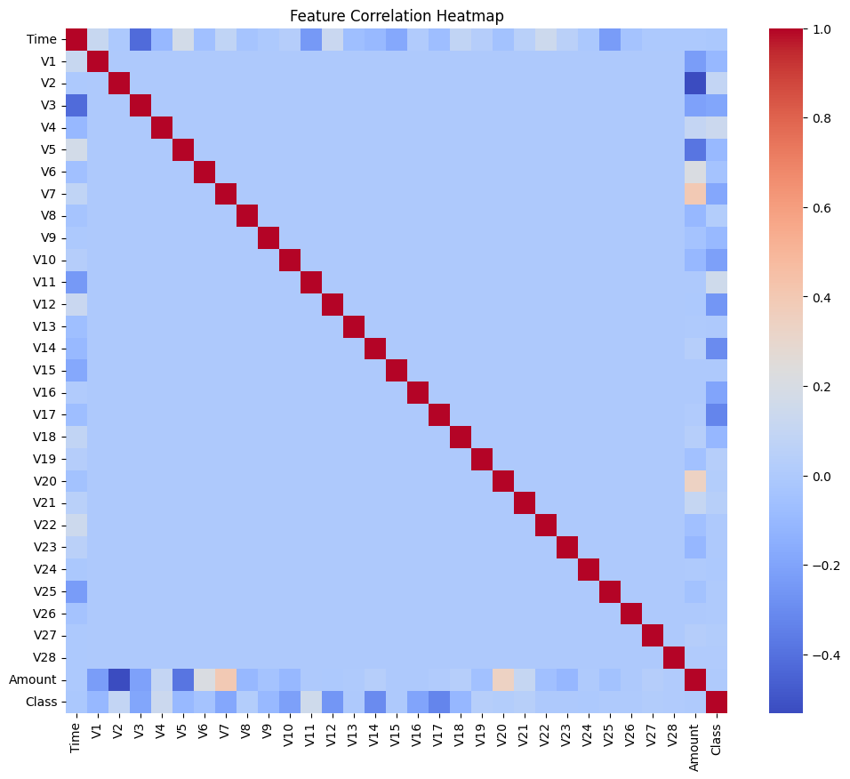

```python
import matplotlib.pyplot as plt
import seaborn as sns

plt.figure(figsize=(12, 10))
sns.heatmap(df.corr(), cmap='coolwarm', annot=False)
plt.title('Feature Correlation Heatmap')
plt.show()
```

**Conclusion:**

#### Box Plots (Distribution by Class)

We will select the top 4 correlated features and create box plots to see if there is a clear "separation" in values between fraud and non-fraud. If the distributions overlap entirely, the predictive task will be harder.

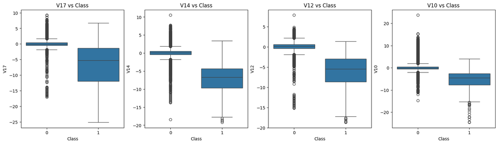

```python
# Visualizing separation in the top 4 highly correlated features
fig, axes = plt.subplots(ncols=4, figsize=(20, 5))

sns.boxplot(x="Class", y="V17", data=df, ax=axes[0])
axes[0].set_title('V17 vs Class')

sns.boxplot(x="Class", y="V14", data=df, ax=axes[1])
axes[1].set_title('V14 vs Class')

sns.boxplot(x="Class", y="V12", data=df, ax=axes[2])
axes[2].set_title('V12 vs Class')

sns.boxplot(x="Class", y="V10", data=df, ax=axes[3])
axes[3].set_title('V10 vs Class')

plt.show()
```